# (FINAL_COPY)_Retention_Classification_Project_ML_Foundations

```python
import math
import pandas as pd
import numpy as np
import matplotlib.pyplot as plt
import seaborn as sns
from sklearn.model_selection import train_test_split
from sklearn.preprocessing import StandardScaler
from sklearn.linear_model import LogisticRegression
from sklearn.neighbors import KNeighborsClassifier
from sklearn.ensemble import RandomForestClassifier
import xgboost as xgb
from sklearn.metrics import accuracy_score, confusion_matrix, classification_report, ConfusionMatrixDisplay
from google.colab import drive
from google.colab import files
```

## Read Dataset

```python
# Load an CSV file
file_path = 'https://www.dropbox.com/scl/fi/hsh5kfc52hv57pkjq3crp/scholastic_travel.csv?rlkey=lzmscfrwl7wfrlgxdhc469zss&st=0c5kf8b9&dl=1'
ogdata = pd.read_csv(file_path)

ogdata.head()

# Make a copy of the data for later use
data_viz = ogdata.copy()
```

## Data Exploration

```python
# Step 1: We will start by loading the data and doing basic inspection

# Inspect the shape of the dataset
print("Dataset shape (rows, columns):", ogdata.shape)

# Preview the first few rows
display(ogdata.head())

# Review data types for each column
display(ogdata.dtypes.value_counts())
display(ogdata.dtypes)

# Summary statistics for numeric columns
display(ogdata.describe().T)

# Check distribution of our target variable
print("\nTarget Variable Distribution:")
print(ogdata['RetainedLabel'].value_counts())
print(ogdata['RetainedLabel'].value_counts(normalize=True).round(3))
```

```
Dataset shape (rows, columns): (2389, 55)
```

|  | ProgramCode | FromGrade | ToGrade | GroupState | IsNonAnnual | Days | TravelType | DepartureDate | ReturnDate | DepositDate | ... | GroupGradeTypeLow | GroupGradeTypeHigh | GroupGradeType | MajorProgramCode | SingleGradeTripFlag | FPPtoSchoolenrollment | FPPtoPAX | NumofNonFPPPAX | SchoolSizeIndicator | RetainedLabel |
| --- | --- | --- | --- | --- | --- | --- | --- | --- | --- | --- | --- | --- | --- | --- | --- | --- | --- | --- | --- | --- | --- |
| 0 | HS | 4 | 4 | CA | 0 | 1 | A | 1/14/11 | 1/14/11 | 8/30/10 | ... | K | Elementary | K->Elementary | H | 1 | 0.063646 | 0.936508 | 4 | L | Retained |
| 1 | HC | 8 | 8 | AZ | 0 | 7 | A | 1/14/11 | 1/21/11 | 11/15/09 | ... | Middle | Middle | Middle->Middle | H | 1 | 0.025882 | 0.880000 | 3 | L | Retained |
| 2 | HD | 8 | 8 | FL | 0 | 3 | A | 1/15/11 | 1/17/11 | 10/15/10 | ... | Middle | Middle | Middle->Middle | H | 1 | 0.025131 | 0.888889 | 3 | L | Retained |
| 3 | HN | 9 | 12 | Other | 1 | 3 | B | 1/15/11 | 1/17/11 | 1/7/11 | ... | Undefined | Undefined | Undefined->Undefined | H | 0 | 0.000000 | 1.000000 | 0 | FIXED_NA | Churned |
| 4 | HD | 6 | 8 | FL | 0 | 6 | Other | 1/16/11 | 1/21/11 | 9/30/10 | ... | Middle | Middle | Middle->Middle | H | 0 | 0.112500 | 0.910112 | 8 | M-L | Churned |

5 rows × 55 columns

|  | count |
| --- | --- |
| object | 29 |
| int64 | 22 |
| float64 | 4 |

**dtype:** int64

|  | 0 |
| --- | --- |
| ProgramCode | object |
| FromGrade | int64 |
| ToGrade | int64 |
| GroupState | object |
| IsNonAnnual | int64 |
| Days | int64 |
| TravelType | object |
| DepartureDate | object |
| ReturnDate | object |
| DepositDate | object |
| SpecialPay | object |
| Tuition | int64 |
| FRPActive | int64 |
| FRPCancelled | int64 |
| FRPTakeuppercent | float64 |
| EarlyRPL | object |
| LatestRPL | object |
| CancelledPax | int64 |
| TotalDiscountPax | int64 |
| InitialSystemDate | object |
| PovertyCode | object |
| Region | object |
| CRMSegment | int64 |
| SchoolType | object |
| ParentMeetingFlag | int64 |
| MDRLowGrade | object |
| MDRHighGrade | int64 |
| TotalSchoolEnrollment | int64 |
| IncomeLevel | object |
| EZPayTakeUpRate | float64 |
| SchoolSponsor | int64 |
| SPRProductType | object |
| SPRNewExisting | object |
| FPP | int64 |
| TotalPax | int64 |
| SPRGroupRevenue | int64 |
| NumberOfMeetingswithParents | int64 |
| FirstMeeting | object |
| LastMeeting | object |
| DifferenceTraveltoFirstMeeting | int64 |
| DifferenceTraveltoLastMeeting | int64 |
| SchoolGradeTypeLow | object |
| SchoolGradeTypeHigh | object |
| SchoolGradeType | object |
| DepartureMonth | object |
| GroupGradeTypeLow | object |
| GroupGradeTypeHigh | object |
| GroupGradeType | object |
| MajorProgramCode | object |
| SingleGradeTripFlag | int64 |
| FPPtoSchoolenrollment | float64 |
| FPPtoPAX | float64 |
| NumofNonFPPPAX | int64 |
| SchoolSizeIndicator | object |
| RetainedLabel | object |

**dtype:** object

|  | count | mean | std | min | 25% | 50% | 75% | max |
| --- | --- | --- | --- | --- | --- | --- | --- | --- |
| FromGrade | 2389.0 | 6.881959 | 2.117834 | 0.0 | 6.000000 | 8.000000 | 8.000000 | 12.000000 |
| ToGrade | 2389.0 | 7.416074 | 2.441649 | 0.0 | 8.000000 | 8.000000 | 8.000000 | 12.000000 |
| IsNonAnnual | 2389.0 | 0.154039 | 0.361062 | 0.0 | 0.000000 | 0.000000 | 0.000000 | 1.000000 |
| Days | 2389.0 | 4.575136 | 1.432128 | 1.0 | 4.000000 | 5.000000 | 5.000000 | 12.000000 |
| Tuition | 2389.0 | 1615.217664 | 645.096047 | 79.0 | 1174.000000 | 1700.000000 | 2048.000000 | 4200.000000 |
| FRPActive | 2389.0 | 16.867727 | 16.942782 | 0.0 | 6.000000 | 12.000000 | 23.000000 | 257.000000 |
| FRPCancelled | 2389.0 | 3.305567 | 3.677022 | 0.0 | 1.000000 | 2.000000 | 4.000000 | 45.000000 |
| FRPTakeuppercent | 2389.0 | 0.570743 | 0.230666 | 0.0 | 0.455000 | 0.600000 | 0.727000 | 1.000000 |
| CancelledPax | 2389.0 | 4.807451 | 4.661194 | 0.0 | 2.000000 | 4.000000 | 6.000000 | 39.000000 |
| TotalDiscountPax | 2389.0 | 2.953537 | 2.876422 | 0.0 | 1.000000 | 2.000000 | 4.000000 | 47.000000 |
| CRMSegment | 2389.0 | 6.908748 | 2.757668 | 0.0 | 5.000000 | 6.000000 | 10.000000 | 11.000000 |
| ParentMeetingFlag | 2389.0 | 0.858937 | 0.348160 | 0.0 | 1.000000 | 1.000000 | 1.000000 | 1.000000 |
| MDRHighGrade | 2389.0 | 8.153202 | 2.216121 | 0.0 | 8.000000 | 8.000000 | 8.000000 | 12.000000 |
| TotalSchoolEnrollment | 2389.0 | 623.661783 | 422.455544 | 0.0 | 338.000000 | 575.000000 | 811.000000 | 3990.000000 |
| EZPayTakeUpRate | 2389.0 | 0.207943 | 0.155654 | 0.0 | 0.100000 | 0.200000 | 0.292000 | 1.750000 |
| SchoolSponsor | 2389.0 | 0.105902 | 0.307777 | 0.0 | 0.000000 | 0.000000 | 0.000000 | 1.000000 |
| FPP | 2389.0 | 31.297195 | 29.131503 | 2.0 | 12.000000 | 23.000000 | 41.000000 | 286.000000 |
| TotalPax | 2389.0 | 34.250733 | 31.590096 | 2.0 | 14.000000 | 26.000000 | 44.000000 | 313.000000 |
| SPRGroupRevenue | 2389.0 | 1615.217664 | 645.096047 | 79.0 | 1174.000000 | 1700.000000 | 2048.000000 | 4200.000000 |
| NumberOfMeetingswithParents | 2389.0 | 1.102135 | 0.611544 | 0.0 | 1.000000 | 1.000000 | 1.000000 | 2.000000 |
| DifferenceTraveltoFirstMeeting | 2389.0 | 225.113437 | 117.290653 | -204.0 | 187.000000 | 238.000000 | 277.000000 | 749.000000 |
| DifferenceTraveltoLastMeeting | 2389.0 | 196.677689 | 93.948193 | -204.0 | 179.000000 | 220.000000 | 258.000000 | 749.000000 |
| SingleGradeTripFlag | 2389.0 | 0.556718 | 0.496877 | 0.0 | 0.000000 | 1.000000 | 1.000000 | 1.000000 |
| FPPtoSchoolenrollment | 2389.0 | 0.063663 | 0.080554 | 0.0 | 0.018397 | 0.043339 | 0.085766 | 2.052632 |
| FPPtoPAX | 2389.0 | 0.900667 | 0.049119 | 0.6 | 0.882353 | 0.909091 | 0.933333 | 1.000000 |
| NumofNonFPPPAX | 2389.0 | 2.953537 | 2.876422 | 0.0 | 1.000000 | 2.000000 | 4.000000 | 47.000000 |

```
Target Variable Distribution:
RetainedLabel
Retained    1451
Churned      938
Name: count, dtype: int64
RetainedLabel
Retained    0.607
Churned     0.393
Name: proportion, dtype: float64
```

**Important Findings:**

- The target variable is moderately imbalanced at 61% Retained / 39% Churned. This is acceptable for modeling without resampling techniques, but means accuracy alone can be misleading.
- DifferenceTraveltoFirstMeeting and DifferenceTraveltoLastMeeting both have a min of -204 but are supposed to represent number of days. This raises a potential data quality issue.
- There are data fields with identical data values (NumofNonFPPPAX and TotalDiscountPax) and (SPRGroupRevenue and Tuition)

```python
# Step 2: Next we will diagnose fields for data quality by inspecting for missing values and by flagging unintuitive values

# Check for missing values and duplicates
missing_values = ogdata.isna().sum().sort_values(ascending=False)
missing_summary = pd.DataFrame({
    "missing_count": missing_values,
    "missing_pct": (missing_values / len(ogdata) * 100).round(2)
})
display(missing_summary[missing_summary["missing_count"] > 0])
print("Duplicate rows:", ogdata.duplicated().sum())

# Flag unintuitive values
print("\nUnintuitive Value Flags:")
print(f"  Negative DifferenceTraveltoFirstMeeting: {(ogdata['DifferenceTraveltoFirstMeeting'] < 0).sum()} rows")
print(f"  Negative DifferenceTraveltoLastMeeting:  {(ogdata['DifferenceTraveltoLastMeeting'] < 0).sum()} rows")
print(f"  EZPayTakeUpRate > 1 (impossible rate):   {(ogdata['EZPayTakeUpRate'] > 1).sum()} rows")
print(f"  FPPtoSchoolenrollment > 1 (anomaly):     {(ogdata['FPPtoSchoolenrollment'] > 1).sum()} rows")

# Clip drop fields with unintuitive values below 0 or percentages above 100%
ogdata['DifferenceTraveltoFirstMeeting'] = ogdata['DifferenceTraveltoFirstMeeting'].clip(lower=0)
ogdata['DifferenceTraveltoLastMeeting'] = ogdata['DifferenceTraveltoLastMeeting'].clip(lower=0)
ogdata['EZPayTakeUpRate'] = ogdata['EZPayTakeUpRate'].clip(upper=1.0)
ogdata['FPPtoSchoolenrollment'] = ogdata['FPPtoSchoolenrollment'].clip(upper=1.0)

print("\nValues capped. Data shape unchanged:", ogdata.shape)
```

|  | missing_count | missing_pct |
| --- | --- | --- |

```
Duplicate rows: 0

Unintuitive Value Flags:
  Negative DifferenceTraveltoFirstMeeting: 2 rows
  Negative DifferenceTraveltoLastMeeting:  4 rows
  EZPayTakeUpRate > 1 (impossible rate):   2 rows
  FPPtoSchoolenrollment > 1 (anomaly):     2 rows

Values capped. Data shape unchanged: (2389, 55)
```

## Data Preprocesssing

```python
# Step 3: Next we will move onto shaping our working dataset(s) by dropping irrelevant and redundant columns

# Raw date columns - already captured by engineered numeric features
# (e.g. DifferenceTraveltoFirstMeeting, DepartureMonth)
date_cols = ['DepartureDate', 'ReturnDate', 'DepositDate', 'EarlyRPL',
             'LatestRPL', 'InitialSystemDate', 'FirstMeeting', 'LastMeeting']

# Confirmed exact duplicates
# SPRGroupRevenue == Tuition (every row identical)
# NumofNonFPPPAX == TotalDiscountPax (every row identical)
exact_duplicates = ['SPRGroupRevenue', 'NumofNonFPPPAX']

# Redundant combined columns - SchoolGradeType and GroupGradeType are just
# concatenations of their Low/High counterparts, keeping combined version only
redundant_grade_cols = ['SchoolGradeTypeLow', 'SchoolGradeTypeHigh',
                        'GroupGradeTypeLow', 'GroupGradeTypeHigh']

# Drop all identified columns
cols_to_drop = date_cols + exact_duplicates + redundant_grade_cols
data = ogdata.drop(columns=cols_to_drop, errors='ignore')

print(f" Dropped {len(cols_to_drop)} columns:")
print(f"  Raw date columns:      {len(date_cols)}")
print(f"  Exact duplicates:      {len(exact_duplicates)}")
print(f"  Redundant grade cols:  {len(redundant_grade_cols)}")
print(f"\nDataset shape after dropping: {data.shape}")
```

```
 Dropped 14 columns:
  Raw date columns:      8
  Exact duplicates:      2
  Redundant grade cols:  4

Dataset shape after dropping: (2389, 41)
```

```python
# Step 4: Next we will encode categorical variables so that they can be considered as modeling inputs

# --- Encode Target Variable ---
# Retained = 1, Churned = 0
data['RetainedLabel'] = data['RetainedLabel'].map({'Retained': 1, 'Churned': 0})

# --- Ordinal Encoding ---
# For columns with a clear natural order, we map categories to ordered numbers
# rather than treating them as independent categories

poverty_order = {'A': 1, 'B': 2, 'C': 3, 'Other': 4, 'FIXED_NA': 0}
data['PovertyCode'] = data['PovertyCode'].map(poverty_order)

size_order = {'S': 1, 'S-M': 2, 'M-L': 3, 'L': 4, 'FIXED_NA': 0}
data['SchoolSizeIndicator'] = data['SchoolSizeIndicator'].map(size_order)

income_order = {'C': 1, 'E': 2, 'F': 3, 'G': 4, 'H': 5, 'I': 6, 'J': 7,
                'K': 8, 'L': 9, 'M': 10, 'N': 11, 'O': 12, 'P': 13, 'Q': 14,
                'Other': 15, 'FIXED_NA': 0}
data['IncomeLevel'] = data['IncomeLevel'].map(income_order)

print("Ordinal encoding complete:")
print(f"  PovertyCode unique values:         {sorted(data['PovertyCode'].unique())}")
print(f"  SchoolSizeIndicator unique values:  {sorted(data['SchoolSizeIndicator'].unique())}")
print(f"  IncomeLevel unique values:          {sorted(data['IncomeLevel'].unique())}")

# --- One-Hot Encoding ---
# For all remaining categorical columns with no natural order
cat_cols = data.select_dtypes(include='object').columns.tolist()
print(f"\nOne-hot encoding {len(cat_cols)} remaining categorical columns:")
print(cat_cols)

data = pd.get_dummies(data, columns=cat_cols, drop_first=True, dtype=int)

print(f"\nDataset shape after encoding: {data.shape}")
display(data.head())
```

```
Ordinal encoding complete:
  PovertyCode unique values:         [np.int64(0), np.int64(1), np.int64(2), np.int64(3), np.int64(4)]
  SchoolSizeIndicator unique values:  [np.int64(0), np.int64(1), np.int64(2), np.int64(3), np.int64(4)]
  IncomeLevel unique values:          [np.int64(0), np.int64(1), np.int64(2), np.int64(3), np.int64(4), np.int64(5), np.int64(6), np.int64(7), np.int64(8), np.int64(9), np.int64(10), np.int64(11), np.int64(12), np.int64(13), np.int64(14), np.int64(15)]

One-hot encoding 13 remaining categorical columns:
['ProgramCode', 'GroupState', 'TravelType', 'SpecialPay', 'Region', 'SchoolType', 'MDRLowGrade', 'SPRProductType', 'SPRNewExisting', 'SchoolGradeType', 'DepartureMonth', 'GroupGradeType', 'MajorProgramCode']

Dataset shape after encoding: (2389, 93)
```

|  | FromGrade | ToGrade | IsNonAnnual | Days | Tuition | FRPActive | FRPCancelled | FRPTakeuppercent | CancelledPax | TotalDiscountPax | ... | GroupGradeType_K->Middle | GroupGradeType_Middle->High | GroupGradeType_Middle->Middle | GroupGradeType_Other | GroupGradeType_PK->High | GroupGradeType_PK->Middle | GroupGradeType_Undefined->Undefined | MajorProgramCode_H | MajorProgramCode_Other | MajorProgramCode_S |
| --- | --- | --- | --- | --- | --- | --- | --- | --- | --- | --- | --- | --- | --- | --- | --- | --- | --- | --- | --- | --- | --- |
| 0 | 4 | 4 | 0 | 1 | 424 | 25 | 3 | 0.424 | 3 | 4 | ... | 0 | 0 | 0 | 0 | 0 | 0 | 0 | 1 | 0 | 0 |
| 1 | 8 | 8 | 0 | 7 | 2350 | 9 | 9 | 0.409 | 11 | 3 | ... | 0 | 0 | 1 | 0 | 0 | 0 | 0 | 1 | 0 | 0 |
| 2 | 8 | 8 | 0 | 3 | 1181 | 17 | 6 | 0.708 | 6 | 3 | ... | 0 | 0 | 1 | 0 | 0 | 0 | 0 | 1 | 0 | 0 |
| 3 | 9 | 12 | 1 | 3 | 376 | 0 | 0 | 0.000 | 1 | 0 | ... | 0 | 0 | 0 | 0 | 0 | 0 | 1 | 1 | 0 | 0 |
| 4 | 6 | 8 | 0 | 6 | 865 | 40 | 8 | 0.494 | 9 | 8 | ... | 0 | 0 | 1 | 0 | 0 | 0 | 0 | 1 | 0 | 0 |

5 rows × 93 columns

```python
# Step 5: Next, we will scale numeric variables so that all features contribute equally to the model
# We will only scale the continuous numeric columns - binary and ordinal columns are left as-is

from sklearn.preprocessing import StandardScaler

# Identify continuous numeric columns to scale
# Excludes binary flags (0/1), ordinal encoded columns, and the target variable
cols_to_scale = [
    'FromGrade', 'ToGrade', 'Days', 'Tuition', 'FRPActive', 'FRPCancelled',
    'FRPTakeuppercent', 'CancelledPax', 'TotalDiscountPax', 'CRMSegment',
    'MDRHighGrade', 'TotalSchoolEnrollment', 'EZPayTakeUpRate', 'FPP',
    'TotalPax', 'NumberOfMeetingswithParents', 'DifferenceTraveltoFirstMeeting',
    'DifferenceTraveltoLastMeeting', 'FPPtoSchoolenrollment', 'FPPtoPAX'
]

scaler = StandardScaler()
data[cols_to_scale] = scaler.fit_transform(data[cols_to_scale])

print(f"Scaled {len(cols_to_scale)} continuous numeric columns")
print(f"\nDataset shape unchanged: {data.shape}")
display(data[cols_to_scale].describe().T.round(3))
```

```
Scaled 20 continuous numeric columns

Dataset shape unchanged: (2389, 93)
```

|  | count | mean | std | min | 25% | 50% | 75% | max |
| --- | --- | --- | --- | --- | --- | --- | --- | --- |
| FromGrade | 2389.0 | -0.0 | 1.0 | -3.250 | -0.417 | 0.528 | 0.528 | 2.417 |
| ToGrade | 2389.0 | 0.0 | 1.0 | -3.038 | 0.239 | 0.239 | 0.239 | 1.878 |
| Days | 2389.0 | 0.0 | 1.0 | -2.497 | -0.402 | 0.297 | 0.297 | 5.186 |
| Tuition | 2389.0 | -0.0 | 1.0 | -2.382 | -0.684 | 0.131 | 0.671 | 4.008 |
| FRPActive | 2389.0 | -0.0 | 1.0 | -0.996 | -0.642 | -0.287 | 0.362 | 14.176 |
| FRPCancelled | 2389.0 | 0.0 | 1.0 | -0.899 | -0.627 | -0.355 | 0.189 | 11.342 |
| FRPTakeuppercent | 2389.0 | 0.0 | 1.0 | -2.475 | -0.502 | 0.127 | 0.678 | 1.861 |
| CancelledPax | 2389.0 | -0.0 | 1.0 | -1.032 | -0.602 | -0.173 | 0.256 | 7.337 |
| TotalDiscountPax | 2389.0 | 0.0 | 1.0 | -1.027 | -0.679 | -0.332 | 0.364 | 15.316 |
| CRMSegment | 2389.0 | -0.0 | 1.0 | -2.506 | -0.692 | -0.330 | 1.121 | 1.484 |
| MDRHighGrade | 2389.0 | -0.0 | 1.0 | -3.680 | -0.069 | -0.069 | -0.069 | 1.736 |
| TotalSchoolEnrollment | 2389.0 | 0.0 | 1.0 | -1.477 | -0.676 | -0.115 | 0.444 | 7.970 |
| EZPayTakeUpRate | 2389.0 | 0.0 | 1.0 | -1.359 | -0.704 | -0.049 | 0.553 | 5.188 |
| FPP | 2389.0 | -0.0 | 1.0 | -1.006 | -0.663 | -0.285 | 0.333 | 8.745 |
| TotalPax | 2389.0 | 0.0 | 1.0 | -1.021 | -0.641 | -0.261 | 0.309 | 8.826 |
| NumberOfMeetingswithParents | 2389.0 | -0.0 | 1.0 | -1.803 | -0.167 | -0.167 | -0.167 | 1.469 |
| DifferenceTraveltoFirstMeeting | 2389.0 | -0.0 | 1.0 | -1.929 | -0.328 | 0.109 | 0.443 | 4.483 |
| DifferenceTraveltoLastMeeting | 2389.0 | -0.0 | 1.0 | -2.108 | -0.191 | 0.248 | 0.655 | 5.912 |
| FPPtoSchoolenrollment | 2389.0 | 0.0 | 1.0 | -0.913 | -0.646 | -0.285 | 0.329 | 13.565 |
| FPPtoPAX | 2389.0 | -0.0 | 1.0 | -6.123 | -0.373 | 0.172 | 0.665 | 2.023 |

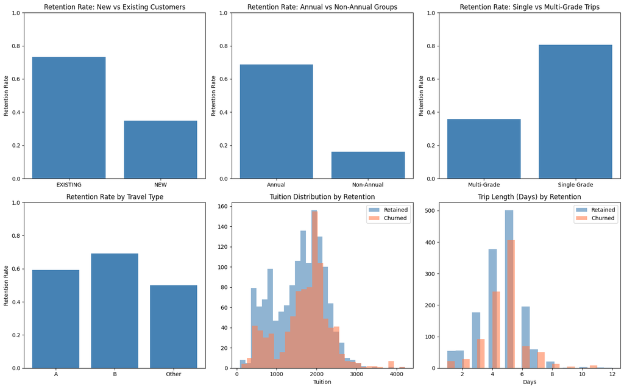

```python
# Step 6: Visualize key variables vs Retention Rate to start to identify signals behind churn

# Using the original data (pre-encoding) for readability in plots
fig, axes = plt.subplots(2, 3, figsize=(16, 10))
axes = axes.flatten()

# 1. SPRNewExisting - new vs existing customers
retention_by_new_existing = data_viz.groupby('SPRNewExisting')['RetainedLabel'].apply(
    lambda x: (x == 'Retained').mean()
)
axes[0].bar(retention_by_new_existing.index, retention_by_new_existing.values, color='steelblue')
axes[0].set_title('Retention Rate: New vs Existing Customers')
axes[0].set_ylabel('Retention Rate')
axes[0].set_ylim(0, 1)

# 2. IsNonAnnual
retention_by_nonannual = data_viz.groupby('IsNonAnnual')['RetainedLabel'].apply(
    lambda x: (x == 'Retained').mean()
)
axes[1].bar(['Annual', 'Non-Annual'], retention_by_nonannual.values, color='steelblue')
axes[1].set_title('Retention Rate: Annual vs Non-Annual Groups')
axes[1].set_ylabel('Retention Rate')
axes[1].set_ylim(0, 1)

# 3. SingleGradeTripFlag
retention_by_singlegrade = data_viz.groupby('SingleGradeTripFlag')['RetainedLabel'].apply(
    lambda x: (x == 'Retained').mean()
)
axes[2].bar(['Multi-Grade', 'Single Grade'], retention_by_singlegrade.values, color='steelblue')
axes[2].set_title('Retention Rate: Single vs Multi-Grade Trips')
axes[2].set_ylabel('Retention Rate')
axes[2].set_ylim(0, 1)

# 4. TravelType
retention_by_travel = data_viz.groupby('TravelType')['RetainedLabel'].apply(
    lambda x: (x == 'Retained').mean()
)
axes[3].bar(retention_by_travel.index, retention_by_travel.values, color='steelblue')
axes[3].set_title('Retention Rate by Travel Type')
axes[3].set_ylabel('Retention Rate')
axes[3].set_ylim(0, 1)

# 5. Tuition distribution by retention
retained = data_viz[data_viz['RetainedLabel'] == 'Retained']['Tuition']
churned = data_viz[data_viz['RetainedLabel'] == 'Churned']['Tuition']
axes[4].hist(retained, bins=30, alpha=0.6, label='Retained', color='steelblue')
axes[4].hist(churned, bins=30, alpha=0.6, label='Churned', color='coral')
axes[4].set_title('Tuition Distribution by Retention')
axes[4].set_xlabel('Tuition')
axes[4].legend()

# 6. Days distribution by retention
retained_days = data_viz[data_viz['RetainedLabel'] == 'Retained']['Days']
churned_days = data_viz[data_viz['RetainedLabel'] == 'Churned']['Days']
axes[5].hist(retained_days, bins=20, alpha=0.6, label='Retained', color='steelblue')
axes[5].hist(churned_days, bins=20, alpha=0.6, label='Churned', color='coral')
axes[5].set_title('Trip Length (Days) by Retention')
axes[5].set_xlabel('Days')
axes[5].legend()

plt.tight_layout()
plt.show()
```

**Important Findings:**

- **New vs Existing** - existing customers retain at 73% vs 35% for new, the single strongest categorical signal in the data
- **Annual vs Non-Annual** - non-annual groups retain at only 16%, a sure sign of churn
- **Single vs Multi-Grade** - single grade trips retain at 80% vs 36%, a very strong signal
- **Travel Type** - bus groups (B) retain at 69% vs 59% for air, a modest but interesting difference
- **Tuition** - distributions overlap heavily, suggesting that tuition is not a strong predictor on its own
- **Days** - same story, distributions overlap with retained groups slightly skewed towards 5 day trips

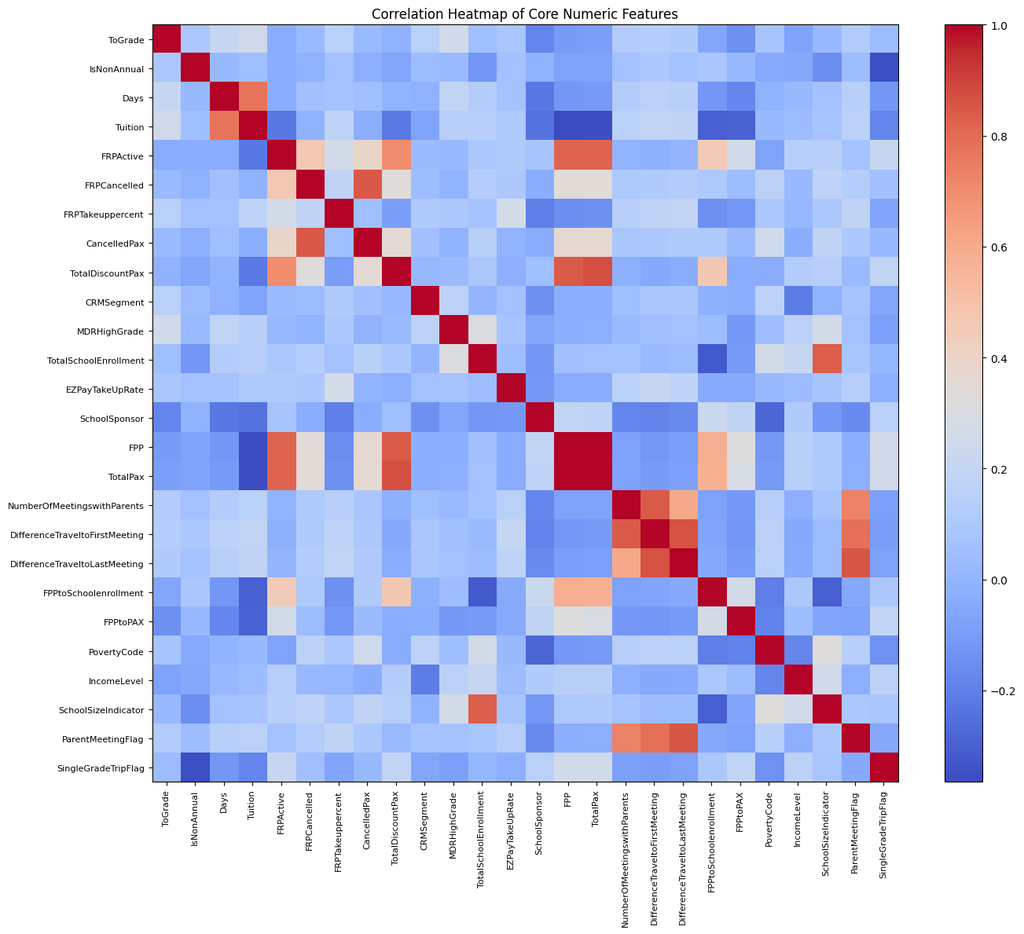

```
Top 15 most correlated feature pairs:
```

|  | Feature 1 | Feature 2 | Correlation |
| --- | --- | --- | --- |
| 0 | MDRLowGrade_FIXED_NA | GroupGradeType_Undefined->Undefined | 1.000000 |
| 1 | FPP | TotalPax | 0.998789 |
| 2 | MDRLowGrade_9 | GroupGradeType_High->High | 0.985234 |
| 3 | TotalDiscountPax | TotalPax | 0.867006 |
| 4 | DifferenceTraveltoFirstMeeting | DifferenceTraveltoLastMeeting | 0.863219 |
| 5 | SPRProductType_Science | MajorProgramCode_S | 0.860882 |
| 6 | FromGrade | ToGrade | 0.858440 |
| 7 | ParentMeetingFlag | DifferenceTraveltoLastMeeting | 0.854181 |
| 8 | GroupState_WA | Region_Pacific Northwest | 0.851784 |
| 9 | FRPCancelled | CancelledPax | 0.850347 |
| 10 | TotalDiscountPax | FPP | 0.841439 |
| 11 | NumberOfMeetingswithParents | DifferenceTraveltoFirstMeeting | 0.841337 |
| 12 | TotalSchoolEnrollment | SchoolSizeIndicator | 0.830064 |
| 13 | MDRLowGrade_K | GroupGradeType_K->Middle | 0.818876 |
| 14 | FRPActive | TotalPax | 0.815460 |

```
Dropped highly correlated columns: ['TotalPax', 'DifferenceTraveltoLastMeeting', 'FromGrade', 'MajorProgramCode_S', 'Region_Pacific Northwest', 'SchoolSizeIndicator']
Final dataset shape: (2389, 87)
```

```python
# Step 7: Now we will conduct correlation analysis to identify highly correlated or identical variables, allowing us to drop remaining redundant columns

# For readability, we visualize only the core numeric columns (pre-encoding)
# This keeps the heatmap interpretable rather than plotting all 90+ encoded columns
core_numeric_cols = [
    'ToGrade', 'IsNonAnnual', 'Days', 'Tuition', 'FRPActive', 'FRPCancelled',
    'FRPTakeuppercent', 'CancelledPax', 'TotalDiscountPax', 'CRMSegment',
    'MDRHighGrade', 'TotalSchoolEnrollment', 'EZPayTakeUpRate', 'SchoolSponsor',
    'FPP', 'TotalPax', 'NumberOfMeetingswithParents', 'DifferenceTraveltoFirstMeeting',
    'DifferenceTraveltoLastMeeting', 'FPPtoSchoolenrollment', 'FPPtoPAX',
    'PovertyCode', 'IncomeLevel', 'SchoolSizeIndicator', 'ParentMeetingFlag',
    'SingleGradeTripFlag'
]

corr_matrix_core = data[core_numeric_cols].corr()
plt.figure(figsize=(14, 12))
plt.imshow(corr_matrix_core, aspect='auto', cmap='coolwarm')
plt.colorbar()
plt.xticks(range(len(core_numeric_cols)), core_numeric_cols, rotation=90, fontsize=8)
plt.yticks(range(len(core_numeric_cols)), core_numeric_cols, fontsize=8)
plt.title('Correlation Heatmap of Core Numeric Features')
plt.tight_layout()
plt.show()

# Run full correlation across all encoded columns to identify redundant pairs
numeric_cols = data.select_dtypes(include=['int64', 'float64']).columns.tolist()
numeric_cols = [col for col in numeric_cols if col != 'RetainedLabel']
corr_matrix = data[numeric_cols].corr()

# Print top correlated pairs
corr_pairs = (
    corr_matrix.abs()
    .where(np.triu(np.ones(corr_matrix.shape), k=1).astype(bool))
    .stack()
    .sort_values(ascending=False)
)
print("Top 15 most correlated feature pairs:")
display(corr_pairs.head(15).reset_index().rename(columns={
    'level_0': 'Feature 1', 'level_1': 'Feature 2', 0: 'Correlation'
}))

# Drop highly correlated variables (correlation > 0.85)
cols_to_drop_corr = ['TotalPax', 'DifferenceTraveltoLastMeeting', 'FromGrade',
                     'MajorProgramCode_S', 'Region_Pacific Northwest', 'SchoolSizeIndicator']
data = data.drop(columns=cols_to_drop_corr, errors='ignore')

print(f"\nDropped highly correlated columns: {cols_to_drop_corr}")
print(f"Final dataset shape: {data.shape}")
```

```python
# Step 8: Now we can finish out the EDA by creating a clean dataframes output for modeling
# We will create three versions: full, quantitative only, and qualitative only

# --- Full clean dataframe ---
# Already stored in 'data'
print(f"Full clean dataset shape: {data.shape}")
display(data.head())

# --- Quantitative only ---
# Continuous and ordinal numeric columns only, excludes one-hot encoded dummies
quant_cols = [
    'ToGrade', 'IsNonAnnual', 'Days', 'Tuition', 'FRPActive', 'FRPCancelled',
    'FRPTakeuppercent', 'CancelledPax', 'TotalDiscountPax', 'CRMSegment',
    'MDRHighGrade', 'TotalSchoolEnrollment', 'EZPayTakeUpRate', 'SchoolSponsor',
    'FPP', 'NumberOfMeetingswithParents', 'DifferenceTraveltoFirstMeeting',
    'FPPtoSchoolenrollment', 'FPPtoPAX', 'ParentMeetingFlag', 'SingleGradeTripFlag',
    'PovertyCode', 'IncomeLevel', 'RetainedLabel'
]
data_quant = data[quant_cols]
print(f"\nQuantitative only dataset shape: {data_quant.shape}")
display(data_quant.head())

# --- Qualitative only ---
# One-hot encoded dummy columns plus target variable
qual_cols = [col for col in data.columns if col not in quant_cols] + ['RetainedLabel']
data_qual = data[qual_cols]
print(f"\nQualitative only dataset shape: {data_qual.shape}")
display(data_qual.head())

print("\nEDA complete. Three dataframes ready for modeling:")
print(f"  data       — full dataset:          {data.shape}")
print(f"  data_quant — quantitative features: {data_quant.shape}")
print(f"  data_qual  — qualitative features:  {data_qual.shape}")
```

```
Full clean dataset shape: (2389, 87)
```

|  | ToGrade | IsNonAnnual | Days | Tuition | FRPActive | FRPCancelled | FRPTakeuppercent | CancelledPax | TotalDiscountPax | PovertyCode | ... | GroupGradeType_K->High | GroupGradeType_K->Middle | GroupGradeType_Middle->High | GroupGradeType_Middle->Middle | GroupGradeType_Other | GroupGradeType_PK->High | GroupGradeType_PK->Middle | GroupGradeType_Undefined->Undefined | MajorProgramCode_H | MajorProgramCode_Other |
| --- | --- | --- | --- | --- | --- | --- | --- | --- | --- | --- | --- | --- | --- | --- | --- | --- | --- | --- | --- | --- | --- |
| 0 | -1.399377 | 0 | -2.496904 | -1.846961 | 0.480085 | -0.083119 | -0.636306 | -0.387847 | 0.363883 | 2 | ... | 0 | 0 | 0 | 0 | 0 | 0 | 0 | 0 | 1 | 0 |
| 1 | 0.239202 | 0 | 1.693544 | 1.139266 | -0.464468 | 1.548978 | -0.701349 | 1.328811 | 0.016156 | 3 | ... | 0 | 0 | 0 | 1 | 0 | 0 | 0 | 0 | 1 | 0 |
| 2 | 0.239202 | 0 | -1.100088 | -0.673246 | 0.007809 | 0.732929 | 0.595170 | 0.255900 | 0.016156 | 3 | ... | 0 | 0 | 0 | 1 | 0 | 0 | 0 | 0 | 1 | 0 |
| 3 | 1.877782 | 1 | -1.100088 | -1.921384 | -0.995779 | -0.899168 | -2.474848 | -0.817011 | -1.027024 | 0 | ... | 0 | 0 | 0 | 0 | 0 | 0 | 0 | 1 | 1 | 0 |
| 4 | 0.239202 | 0 | 0.995136 | -1.163198 | 1.365603 | 1.276961 | -0.332773 | 0.899647 | 1.754791 | 4 | ... | 0 | 0 | 0 | 1 | 0 | 0 | 0 | 0 | 1 | 0 |

5 rows × 87 columns

```
Quantitative only dataset shape: (2389, 24)
```

|  | ToGrade | IsNonAnnual | Days | Tuition | FRPActive | FRPCancelled | FRPTakeuppercent | CancelledPax | TotalDiscountPax | CRMSegment | ... | FPP | NumberOfMeetingswithParents | DifferenceTraveltoFirstMeeting | FPPtoSchoolenrollment | FPPtoPAX | ParentMeetingFlag | SingleGradeTripFlag | PovertyCode | IncomeLevel | RetainedLabel |
| --- | --- | --- | --- | --- | --- | --- | --- | --- | --- | --- | --- | --- | --- | --- | --- | --- | --- | --- | --- | --- | --- |
| 0 | -1.399377 | 0 | -2.496904 | -1.846961 | 0.480085 | -0.083119 | -0.636306 | -0.387847 | 0.363883 | -1.055006 | ... | 0.951156 | -0.167046 | -0.601625 | 0.008803 | 0.729842 | 1 | 1 | 2 | 14 | 1 |
| 1 | 0.239202 | 0 | 1.693544 | 1.139266 | -0.464468 | 1.548978 | -0.701349 | 1.328811 | 0.016156 | 1.121200 | ... | -0.319213 | 1.468501 | 1.692644 | -0.537923 | -0.420838 | 1 | 1 | 3 | 15 | 1 |
| 2 | 0.239202 | 0 | -1.100088 | -0.673246 | 0.007809 | 0.732929 | 0.595170 | 0.255900 | 0.016156 | 1.121200 | ... | -0.250544 | -0.167046 | -0.867007 | -0.548802 | -0.239832 | 1 | 1 | 3 | 12 | 1 |
| 3 | 1.877782 | 1 | -1.100088 | -1.921384 | -0.995779 | -0.899168 | -2.474848 | -0.817011 | -1.027024 | 0.033097 | ... | -0.456550 | -1.802594 | -1.928535 | -0.912635 | 2.022741 | 0 | 0 | 0 | 0 | 0 |
| 4 | 0.239202 | 0 | 0.995136 | -1.163198 | 1.365603 | 1.276961 | -0.332773 | 0.899647 | 1.754791 | 1.121200 | ... | 1.706510 | -0.167046 | -0.687232 | 0.716085 | 0.192345 | 1 | 0 | 4 | 1 | 0 |

5 rows × 24 columns

```
Qualitative only dataset shape: (2389, 64)
```

|  | ProgramCode_HC | ProgramCode_HD | ProgramCode_HN | ProgramCode_HS | ProgramCode_HVP | ProgramCode_Other | ProgramCode_SK | GroupState_CA | GroupState_CO | GroupState_FL | ... | GroupGradeType_K->Middle | GroupGradeType_Middle->High | GroupGradeType_Middle->Middle | GroupGradeType_Other | GroupGradeType_PK->High | GroupGradeType_PK->Middle | GroupGradeType_Undefined->Undefined | MajorProgramCode_H | MajorProgramCode_Other | RetainedLabel |
| --- | --- | --- | --- | --- | --- | --- | --- | --- | --- | --- | --- | --- | --- | --- | --- | --- | --- | --- | --- | --- | --- |
| 0 | 0 | 0 | 0 | 1 | 0 | 0 | 0 | 1 | 0 | 0 | ... | 0 | 0 | 0 | 0 | 0 | 0 | 0 | 1 | 0 | 1 |
| 1 | 1 | 0 | 0 | 0 | 0 | 0 | 0 | 0 | 0 | 0 | ... | 0 | 0 | 1 | 0 | 0 | 0 | 0 | 1 | 0 | 1 |
| 2 | 0 | 1 | 0 | 0 | 0 | 0 | 0 | 0 | 0 | 1 | ... | 0 | 0 | 1 | 0 | 0 | 0 | 0 | 1 | 0 | 1 |
| 3 | 0 | 0 | 1 | 0 | 0 | 0 | 0 | 0 | 0 | 0 | ... | 0 | 0 | 0 | 0 | 0 | 0 | 1 | 1 | 0 | 0 |
| 4 | 0 | 1 | 0 | 0 | 0 | 0 | 0 | 0 | 0 | 1 | ... | 0 | 0 | 1 | 0 | 0 | 0 | 0 | 1 | 0 | 0 |

5 rows × 64 columns

```
EDA complete. Three dataframes ready for modeling:
  data       — full dataset:          (2389, 87)
  data_quant — quantitative features: (2389, 24)
  data_qual  — qualitative features:  (2389, 64)
```